# Pré-processamento de textos em R

Micael Filipe

13/02/2020

## Linguagem de programação R

A linguagem de programação R pode ser utilizada para desempenhar inumeras tarefas, desde cálculos básicos a, até a realização de análises estatísticas complexas. Além disso, o R também pussui uma gama de recursos para plotagem de gráficos, como personalização de: cor, tipo e tamanho de letra, símbolos, títulos e subtítulos, pontos, linhas, legendas, planos de fundo e entre outros. Os gráficos podem ser usados para obter informações visuais significativas durante a análise de dados ou podem ser exportados em um relatório para apresentações.

Mais que um software que realiza análises estatísticas, R é um ambiente e uma linguagem de programação orientada a objeto. Nele, números, vetores, matrizes, arrays, data frames e listas podem ser armazenados em objetos. A linguagem R pode ser utilizada em diversas áreas e para diversos fins, tais como: pesquisa científica, business analytics, desenvolvimento de software, relatórios statísticos, econometria e análise financeira, ciência sociais, e big data analytics.

## Mineração de textos em R

Além das tarefas já citadas anteriormente, a linguagem R pode ser utilizada para mineração de textos. Mineração de textos pode ser definida como uma metodologia para extração de informações a partir de dados textuais, que tem como base o uso de técnicas de processamento de linguagem natural, recuperação de informação e aprendizado de maquina para tratar os dados a fim de filtar apenas os dados que possam ser úteis para o usuário final.

O processo de mineração de textos pode ser resumido em quatro etapas fundamentais:

- **Coleta de documentos**

  Essa etapa tem como ojetivo a coleta de documentos que irão compor o banco de textos a ser analisado.
- **Pré-processamento**

  Nesa etapa os documentos coletados são estruturados de forma padronizada para que os algoritimos que serão utilizados prosteriormente sejma capazes de fazer a manipulação de todos os documentos. Também são definidos os termos e caracteres especiais que não possuem significado relevante (preposições, artigos, pontuação, cabeçalhos, etc.) que serão removidos do conjunto de textos.
- **Extração de conhecimento**

  Essa etapa consiste na extração do conhecimento por meio da aplicação de algoritimos de extração automática de conhecimento. Os termos são agrupados conforme sua similaridade e interação entre si no conjunto de textos.
- **Avaliação e interpretação dos resultados**

  Por fim, os reultados obtidos são avaliados a fim de determinar se os algoritimos reveleram informações relevantes sobre o conjunto de textos.

### Pré-processamento

Importação dos pacotes a seren utilizados:

```r
options("encoding" = "UTF-8")
options(scipen = 999)
library(stringr)
library(tm)
library(SnowballC)
library(lexiconPT)
library(tidytext)
library(tidyverse)
library(magrittr)
library(stm)
library(ggridges)
library(formattable)
```

Leitura de todos os dados do diretorio para um dataframe:

```r
dados<-"/home/micael/R_envs/text-mining/dados/sbrt_txts/dossies"
txtdf<-readtext::readtext(dados, encoding = "latin1")
```

Tentativa de extração dos títulos dos documentos:

```r
titulo<-NULL
for (i in 1:length(txtdf$text)){
tx<-strsplit(x=txtdf[i,2], "\n")[[1]][2]
titulo[i]<-tx
}
txtdf$titulo<-titulo
```

Limpeza dos arquivos de texto:

```r
txtdf$text<-sub('.*\nConteúdo',"",txtdf$text)
txtdf$text<-sub('.*\nCONTEÚDO',"",txtdf$text)
txtdf$text<-sub('.*\nTítulo',"",txtdf$text)
txtdf$text<-gsub('[1-9][0-9]* Copyright © Serviço Brasileiro de Respostas Técnicas - SBRT - http://www.sbrt.ibict.br',"",txtdf$text)
txtdf$text<-gsub('[1-9][0-9]* Copyright © Serviço Brasileiro de Respostas Técnicas - SBRT - http://www.respostatecnica.org.br',"", txtdf$text)
txtdf$text<-gsub('[1-9][0-9]*\nCopyright © Serviço Brasileiro de Respostas Técnicas - SBRT - http://www.respostatecnica.org.br',"", txtdf$text)
txtdf$text<-gsub('\nCopyright © Serviço Brasileiro de Respostas Técnicas - SBRT - http://www.sbrt.ibict.br\n\n[1-9][0-9]*',"", txtdf$text)
txtdf$text<-gsub('Disponível em: ',"",txtdf$text)
txtdf$text<-str_replace_all(txtdf$text, "[^[:alnum:].:,?!;]", " ")
txtdf$text<-gsub("\\s+", " ", str_trim(txtdf$text))
txtdf$text<-gsub('Copyright Serviço Brasileiro de Respostas Técnicas SBRT http: www.respostatecnica.org.br [1-9][0-9]*',"",txtdf$text)
txtdf$text<-gsub('INTRODUÇÃO',"",txtdf$text)
txtdf$text<-gsub('Introdução',"",txtdf$text)
txtdf$text<-gsub('www.*.br',"",txtdf$text)
txtdf$text<- iconv(txtdf$text, from = "UTF-8", to = "ASCII//TRANSLIT")
```

Palavras que serão removidas dos arquivos de texto:

```r
sw_pt_tm <- tm::stopwords("pt") %>% iconv(from = "UTF-8", to = "ASCII//TRANSLIT")
sbrt_sw <- c("http", "senai", "deve","acesso", "brasil", "devem","www.sbrt.ibict.br",
             "serviço", "brasileiro", "respostas", "técnicas", "técnico",
             "www.respostatecnica.org.br", "pode", "ser","norma","iso", "kg",
             "fig", "fonte", "sbrt", "abnt", "nbr", "tecnica")
sw_pt_tm <- c(sbrt_sw, sw_pt_tm)
```

Apresenta as 50 palavras mais fequentes de todo o o conjunto de textos:

```r
df_palavra <- txtdf %>%
  unnest_tokens(palavra, text) %>%
  filter(!palavra %in% sw_pt_tm)

df_palavra %>%
  count(palavra) %>%
  arrange(desc(n)) %>%
  head(50) %>%
  formattable()
```

| palavra | n |
| --- | --- |
| agua | 4968 |
| producao | 4065 |
| processo | 3822 |
| 1 | 3237 |
| figura | 3146 |
| produtos | 3117 |
| produto | 2976 |
| forma | 2900 |
| 2 | 2626 |
| podem | 2497 |
| 3 | 2360 |
| uso | 2267 |
| sistema | 2198 |
| qualidade | 2179 |
| solo | 2073 |
| maior | 2041 |
| sendo | 2032 |
| plantas | 2018 |
| temperatura | 1977 |
| sobre | 1946 |
| tipo | 1875 |
| residuos | 1831 |
| apos | 1784 |
| outros | 1684 |
| material | 1682 |
| controle | 1662 |
| 5 | 1644 |
| durante | 1582 |
| 4 | 1581 |
| alem | 1538 |
| 20 | 1504 |
| cada | 1490 |
| parte | 1464 |
| atraves | 1460 |
| 2007 | 1434 |
| 10 | 1433 |
| grande | 1429 |
| c | 1428 |
| bem | 1415 |
| al | 1401 |
| et | 1398 |
| meio | 1393 |
| condicoes | 1380 |
| area | 1341 |
| ambiente | 1330 |
| materiais | 1326 |
| desenvolvimento | 1315 |
| onde | 1304 |
| ar | 1296 |
| tempo | 1293 |

Faz o processamento do texto:

```r
proc <- stm::textProcessor(txtdf$text, metadata = txtdf, language = "portuguese",
                           customstopwords = sw_pt_tm)
```

```
## Building corpus...
## Converting to Lower Case...
## Removing punctuation...
## Removing stopwords...
## Remove Custom Stopwords...
## Removing numbers...
## Stemming...
## Creating Output...
```

```r
out <- stm::prepDocuments(proc$documents, proc$vocab, proc$meta,
                          lower.thresh = 10)
```

```
## Removing 34905 of 41020 terms (78416 of 361013 tokens) due to frequency
## Your corpus now has 464 documents, 6115 terms and 282597 tokens.
```

Faz a modelagem de tópicos (10 tópicos):

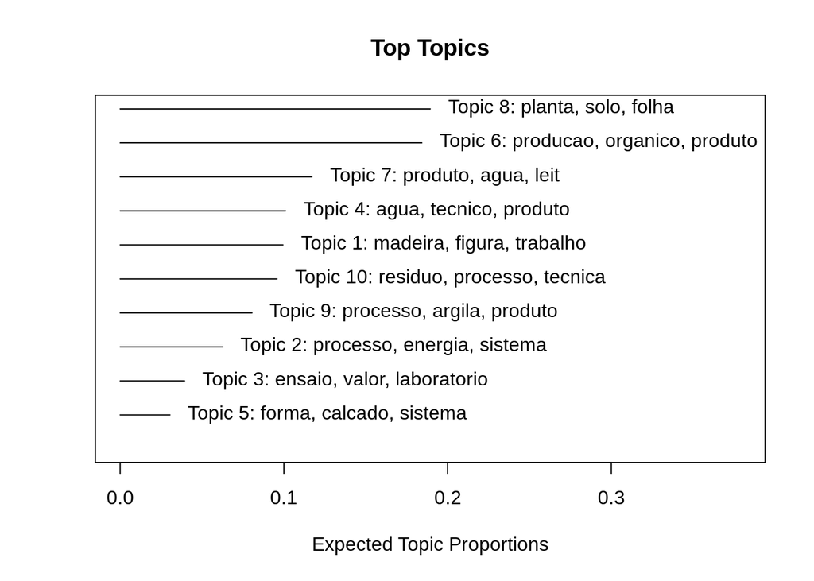

```r
fit <- stm(
  documents = out$documents, vocab = out$vocab, data = out$meta,  K = 10,
  max.em.its = 75, init.type = "Spectral", verbose = FALSE
)
plot(fit, "summary")
```

Apresenta as palavras que mais representa cada tópico (FREX)

```r
stm::labelTopics(fit)
```

```
## Topic 1 Top Words:
##       Highest Prob: madeira, figura, trabalho, cort, peca, produto, maquina
##       FREX: dossi, movei, madeira, cimento, cort, trabalhador, lixa
##       Lift: dossi, mdf, usinagem, macica, lixadeira, layout, confinado
##       Score: dossi, peca, usinagem, madeira, mobiliario, mdf, pastilha
## Topic 2 Top Words:
##       Highest Prob: processo, energia, sistema, agua, temperatura, gas, forma
##       FREX: gas, extrusao, injecao, secador, combustao, solar, etanol
##       Lift: inducao, aquecedor, combustao, ventilador, cabecot, sensor, valvula
##       Score: inducao, extrusao, aquecedor, extrusora, moldagem, film, etanol
## Topic 3 Top Words:
##       Highest Prob: ensaio, valor, laboratorio, amostra, resultado, analis, test
##       FREX: ensaio, laboratorio, retencao, amostra, erro, determinacao, bloco
##       Lift: retencao, chemic, technolog, ensaio, desvio, participant, rubber
##       Score: retencao, ensaio, rubber, participant, medicao, polimero, ceramico
## Topic 4 Top Words:
##       Highest Prob: agua, tecnico, produto, substancia, alimento, podem, uso
##       FREX: tecnico, rdc, desinfeccao, desinfetant, cloro, substancia, anvisa
##       Lift: gram, tecnico, veterinario, febr, rdc, cronica, oral
##       Score: tecnico, rdc, agua, microrganismo, tensoativo, regulamento, anvisa
## Topic 5 Top Words:
##       Highest Prob: forma, calcado, sistema, couro, tratamento, modelo, figura
##       FREX: calcado, lodo, dejeto, bolsa, couro, salto, lagoa
##       Lift: numeracao, dejeto, salto, moda, curtimento, lagoa, calcado
##       Score: numeracao, calcado, lodo, dejeto, couro, suino, efluent
## Topic 6 Top Words:
##       Highest Prob: producao, organico, produto, servico, animai, sistema, organica
##       FREX: servico, animai, cana, organico, agricultura, cogumelo, abelha
##       Lift: pasto, servico, bonotto, degradada, biodiversidad, avicultura, raco
##       Score: servico, cana, raca, certificadora, abelha, cogumelo, mel
## Topic 7 Top Words:
##       Highest Prob: produto, agua, leit, processo, temperatura, acucar, massa
##       FREX: sal, batata, fermentacao, fruta, leit, acucar, fermento
##       Lift: glucos, lactico, vigor, licor, sensori, desnatado, fermentaco
##       Score: vigor, leit, acucar, fermentacao, fruta, carn, queijo
## Topic 8 Top Words:
##       Highest Prob: planta, solo, folha, fruto, sement, plantio, especi
##       FREX: plantio, muda, cultivar, flore, planta, cova, fruto
##       Lift: crisantemo, lagarta, amarelecimento, antracnos, apodrecimento, areno, besouro
##       Score: fruto, plantio, sement, colheita, cultivar, adubacao, praga
## Topic 9 Top Words:
##       Highest Prob: processo, argila, produto, tipo, temperatura, peca, adesivo
##       FREX: argila, ceramica, adesivo, termoplastico, corant, solda, pigmento
##       Lift: polimerica, ondulado, termoplastico, inchamento, latex, caulim, silicato
##       Score: termoplastico, elastomero, argila, solda, ondulado, adesivo, ceramico
## Topic 10 Top Words:
##       Highest Prob: residuo, processo, tecnica, produto, ambient, producao, empresa
##       FREX: tecnica, residuo, reciclagem, limpa, implementacao, emisso, gestao
##       Lift: sucata, tecnica, gerenci, emisso, conama, minimizacao, josean
##       Score: tecnica, efluent, emisso, reciclagem, implementacao, residuo, conama
```

Apresenta gráfico de documento por tópico:

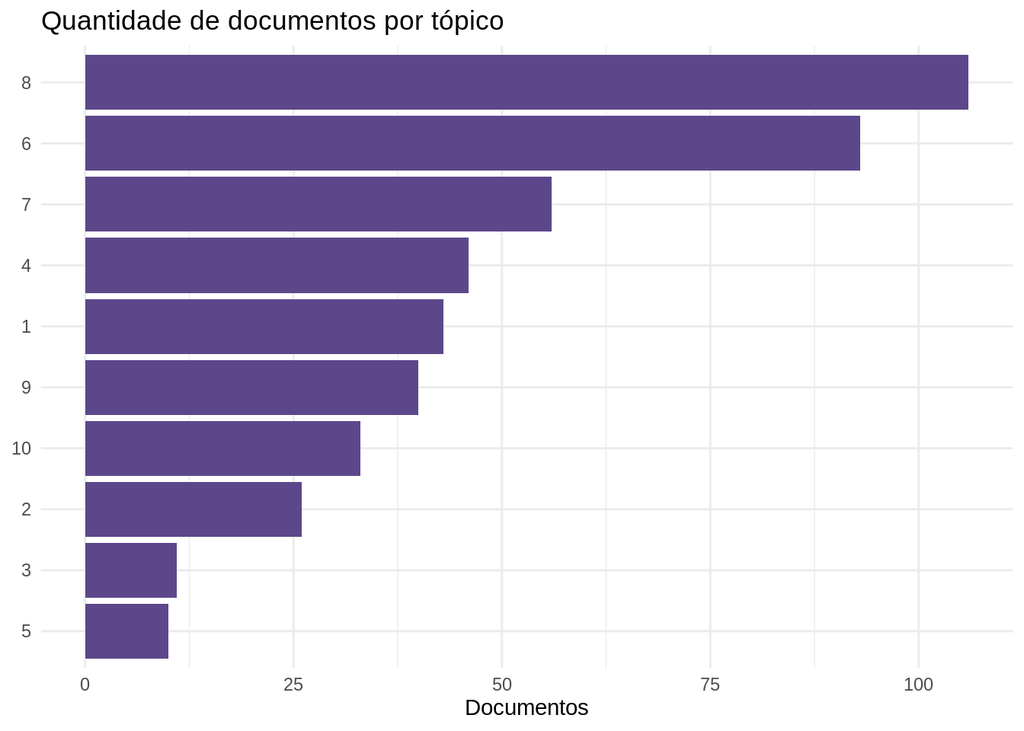

```r
nomes_topicos <- c("1", "2", "3",
                   "4", "5", "6", "7",
                   "8", "9", "10")
maior_prob <- apply(fit$theta, 1, max)
topico_doc <- nomes_topicos[apply(fit$theta, 1, which.max)]

df_topico <- txtdf %>%
  mutate(maior_prob = maior_prob,
         topico = topico_doc)
df_topico %>%
  count(topico) %>%
  mutate(topico = forcats::fct_reorder(topico, n)) %>%
  ggplot(aes(x = topico, y = n)) +
  geom_col(fill = "mediumpurple4") +
  theme_minimal() +
  labs(x = NULL, y = "Documentos",
       title = "Quantidade de documentos por tópico") +
  coord_flip()
```

Cria dataframe com nome do arquivo, titulo e tópico:

```r
topico_doc<-df_topico %>%
  group_by(topico)%>%
  arrange(desc(maior_prob))%>%
  select(titulo,doc_id, topico, maior_prob)
```

Apresenta dos 10 primeiros titulos relacionados ao tópico 1:

```r
topico_doc%>%
  filter(topico==1)%>%
  head(10)%>%
  formattable()
```

| titulo | doc_id | topico | maior_prob |
| --- | --- | --- | --- |
| Sistema de Proteção Coletiva contra Queda de Altura na Indústria da Construção Civil Aledson Damasceno Costa | 157.txt | 1 | 0.9569258 |
| Ergonomia | 158.txt | 1 | 0.9453324 |
| PROCESSOS DE FABRICAÇÃO DE PROTÓTIPOS DE MÓVEIS | 242.txt | 1 | 0.9448476 |
| As condições da falta de segurança dos andaimes como fonte potencial de risco de quedas na construção Civil Aledson Damasceno Costa Rede de Tecnologia da Bahia  RETEC/BA | 80.txt | 1 | 0.9232797 |
| Pastilhas alisadoras Ivan Leandro Debiasi | 48.txt | 1 | 0.9005532 |
| TIPOS DE LAYOUT E SUA APLICAÇÃO NA INDÚSTRIA MOVELEIRA | 240.txt | 1 | 0.8792224 |
| Esquadrias em madeira para portas e janelas Cecilia Chicoski da Silva | 187.txt | 1 | 0.7966342 |
| Montagem e Instalação de móveis | 159.txt | 1 | 0.7670434 |
| Fabricação de shapes de skate Elizabeth Martines | 6112.txt | 1 | 0.7334199 |
| Segurança do trabalho em espaços confinados Mônica Belo Nunes | 5665.txt | 1 | 0.7323084 |

Apresenta dos 10 primeiros titulos relacionados ao tópico 2:

```r
topico_doc%>%
  filter(topico==2)%>%
  head(10)%>%
  formattable()
```

| titulo | doc_id | topico | maior_prob |
| --- | --- | --- | --- |
| Conversão de equipamentos residenciais a gás | 53.txt | 2 | 0.9408900 |
| Sistema de aquecimento solar para uso em instalações hidráulicas residenciais | 272.txt | 2 | 0.9354074 |
| Gás natural veicular (GNV) Sonia Maria Marques de Oliveira | 65.txt | 2 | 0.9212214 |
| Energia térmica na indústria: usos, eficiências e fontes Lothar Hoppe | 5716.txt | 2 | 0.8907280 |
| Eficiência Energética em Processos de Combustão  ganhos ambientais e econômicos | 164.txt | 2 | 0.8646584 |
| Equipamentos e processos de secagem Marina Fernanda Stocco Zempulski Ladislau Nelson Zempulski Instituto de Tecnologia do Paraná | 179.txt | 2 | 0.7992745 |
| Sistemas de Exaustão e Ventilação Industrial Renata Martins | 141.txt | 2 | 0.7923538 |
| Instalação e utilização adequada de uma câmara escura para processamento de filmes radiográficos Otávio Souza Rocha Liz | 264.txt | 2 | 0.7520430 |
| Processo de transformação de plásticos por sopro | 5656.txt | 2 | 0.7074919 |
| Energia Eólica | 5707.txt | 2 | 0.6996507 |

Apresenta dos 10 primeiros titulos relacionados ao tópico 3:

```r
topico_doc%>%
  filter(topico==3)%>%
  head(10)%>%
  formattable()
```

| titulo | doc_id | topico | maior_prob |
| --- | --- | --- | --- |
| Ensaios de Proficiência (ensaios interlaboratoriais) em borracha | 176.txt | 3 | 0.9857795 |
| Ensaios de proficiência para laboratórios de controle da qualidade  componentes para | 47.txt | 3 | 0.9805683 |
| Materiais de Referência Elastoméricos | 271.txt | 3 | 0.9632809 |
|  | 6.txt | 3 | 0.8310904 |
| Análise das Propriedades Dinâmico-Mecânicas em Compostos de Borracha | 268.txt | 3 | 0.7446280 |
| Instrumentalização de um Laboratório para Avaliação do Desempenho, Segurança e Eficiência Energética de Aparelhos Domésticos de Cocção a Gás | 270.txt | 3 | 0.6081691 |
| Análises Instrumentais Aplicadas a Materiais Poliméricos | 269.txt | 3 | 0.5524763 |
| Produção de Embalagem de Papel | 200.txt | 3 | 0.5417856 |
| Reologia escoamento e deformação da matéria | 27657.txt | 3 | 0.5051225 |
| Toxicidade em efluentes industriais | 5648.txt | 3 | 0.4123845 |

Apresenta dos 10 primeiros titulos relacionados ao tópico 4:

```r
topico_doc%>%
  filter(topico==4)%>%
  head(10)%>%
  formattable()
```

| titulo | doc_id | topico | maior_prob |
| --- | --- | --- | --- |
| Água mineral Maria Paula Assis Yamada | 223.txt | 4 | 0.8481740 |
| Desinfetante doméstico Allan George A. Jaigobind | 265.txt | 4 | 0.8234960 |
| Água potável | 9057.txt | 4 | 0.7651539 |
| Fabricação de Cosméticos ea | 32.txt | 4 | 0.7604360 |
| Qualidade microbiológica do ar de ambientes condicionados | 189.txt | 4 | 0.7553373 |
| Qualidade da água de hemodiálise Ivete Keiko Shimada Coimbra Carmen Etsuko Higaskino Eder José dos Santos Maria Paula Assis Yamada Quelcy Barreiros Correa | 216.txt | 4 | 0.6972216 |
| Gestão de Resíduos Sólidos de Saúde Elisabeth Flávia Roberta Oliveira da Motta | 61.txt | 4 | 0.6921906 |
| Alimentos para atletas Janaína Szwaidak Marcelino Marlene Szwaidak Marcelino Instituto de Tecnologia do Paraná | 27615.txt | 4 | 0.6897966 |
| Segurança no trabalho em laboratórios | 5700.txt | 4 | 0.6759809 |
| Tratamento e Controle de Água de Piscina Nelson Alves Góes | 114.txt | 4 | 0.6509216 |

Apresenta dos 10 primeiros titulos relacionados ao tópico 5:

```r
topico_doc%>%
  filter(topico==5)%>%
  head(10)%>%
  formattable()
```

| titulo | doc_id | topico | maior_prob |
| --- | --- | --- | --- |
| Modelagem de bolsas | 15.txt | 5 | 0.9858904 |
| Biossistemas integrados na suinocultura Rogério Moreira de Oliveira | 312.txt | 5 | 0.9821754 |
| Modelagem de bolsas em tecido | 5649.txt | 5 | 0.9719976 |
| Modelagem Técnica do Calçado Mauri Rubem Schmidt | 162.txt | 5 | 0.9431793 |
| Confecção e moda surfwear, beachweare streetwear | 322.txt | 5 | 0.8326793 |
| Fôrmas e sistemas de medidas para calçados Elenilton Gerson Berwanger | 301.txt | 5 | 0.8001477 |
|  | 7.txt | 5 | 0.5929000 |
| Processo de fabricação do calçado | 169.txt | 5 | 0.5476081 |
| Identificação da microfauna presentes em sistema de tratamento tipo Lodo Ativado em curtume | 5677.txt | 5 | 0.5315400 |
| Sumário | 27544.txt | 5 | 0.4782103 |

Apresenta dos 10 primeiros titulos relacionados ao tópico 6:

```r
topico_doc%>%
  filter(topico==6)%>%
  head(10)%>%
  formattable()
```

| titulo | doc_id | topico | maior_prob |
| --- | --- | --- | --- |
| Cunicultura | 5694.txt | 6 | 0.9563981 |
| Bovinocultura | 6105.txt | 6 | 0.9282116 |
| Caprinocultura Orgânica | 5662.txt | 6 | 0.9185144 |
| CUNICULTURA ORGÂNICA Rosa Maria Beraldo | 5718.txt | 6 | 0.9172908 |
| Colheita e processamento de cogumelos comestíveis e medicinais para comercialização | 148.txt | 6 | 0.9051355 |
| Frango Orgânico Lucas José Campanha Ricardo Augusto Bonotto Barboza Universidade Estadual Paulista | 5436.txt | 6 | 0.8965738 |
| Estrutiocultura (criação de avestruz) Lucimar Tunes Leite Instituto de Tecnologia do Paraná | 311.txt | 6 | 0.8740076 |
| Wilton Neves Brandão Rede de Tecnologia da Bahia  RETEC/BA | 122.txt | 6 | 0.8724550 |
| Criação de Codornas Eduardo Henrique da Silva F. Matos Centro de Apoio ao Desenvolvimento Tecnológico da Universidade de Brasília  CDT/UnB | 192.txt | 6 | 0.8659494 |
| Indicações Geográficas aplicadas ao setor de gemas e joias | 27694.txt | 6 | 0.8590737 |

Apresenta dos 10 primeiros titulos relacionados ao tópico 7:

```r
topico_doc%>%
  filter(topico==7)%>%
  head(10)%>%
  formattable()
```

| titulo | doc_id | topico | maior_prob |
| --- | --- | --- | --- |
| ABRIL/2007 | 102.txt | 7 | 0.9949206 |
| Produtos de Soja Lilian Guerreiro REDETEC Rede de Tecnologia do Rio de Janeiro Dezembro / 2006 | 28.txt | 7 | 0.9839339 |
| Doce em Pasta e em Calda Renata Martins | 234.txt | 7 | 0.9766675 |
| Produção de Polpa de Fruta Congelada e Suco de Frutas | 117.txt | 7 | 0.9748032 |
| Fabricação de iogurtes Noely Forlin Robert | 320.txt | 7 | 0.9561191 |
| Processamento de Frutas Cristalizadas Eduardo Henrique da Silva Figueiredo Matos Centro de Apoio ao Desenvolvimento Tecnológico | 109.txt | 7 | 0.9484876 |
| PANIFICAÇÃO Lilian Guerreiro REDETEC Rede de Tecnologia do Rio de janeiro | 27.txt | 7 | 0.9309640 |
| Processamento de conservas e temperos | 55.txt | 7 | 0.8992215 |
| MASSAS ALIMENTÍCIAS Lilian Guerreiro | 26.txt | 7 | 0.8702365 |
| T ecnologia do pescado Ingrid Vieira Machado de Moraes Rede de Tecnologia do Rio de Janeiro | 58.txt | 7 | 0.8630480 |

Apresenta dos 10 primeiros titulos relacionados ao tópico 8:

```r
topico_doc%>%
  filter(topico==8)%>%
  head(10)%>%
  formattable()
```

| titulo | doc_id | topico | maior_prob |
| --- | --- | --- | --- |
| Cultivo de Lírio de corte e de vaso Glecimar Fabrin Pozza | 326.txt | 8 | 0.9930252 |
| Cultivo de Violeta-africana José dos Anjos Soares Júnior | 325.txt | 8 | 0.9743225 |
| Cultivo de Violeta-africana José dos Anjos Soares Júnior | 327.txt | 8 | 0.9743225 |
| Cultivo do Morango Nilva Chaves | 152.txt | 8 | 0.9727960 |
| Cultivo Comercial de Anturium (Anthurium Andreanum Linl) | 323.txt | 8 | 0.9726164 |
| ADUBAÇÃO VERDE Ivo Pessoa Neves | 108.txt | 8 | 0.9695336 |
| Cultivo comercial de Palma de Santa Rita | 83.txt | 8 | 0.9576792 |
| CULTIVO E PROCESSAMENTO DE PIMENTA | 124.txt | 8 | 0.9523446 |
| CULTIVO DE ARROZ IVO PESSOA NEVES Rede de Tecnologia da Bahia  RETEC/BA | 256.txt | 8 | 0.9467304 |
| CULTIVO DE CENOURA IVO PESSOA NEVES | 254.txt | 8 | 0.9451062 |

Apresenta dos 10 primeiros titulos relacionados ao tópico 9:

```r
topico_doc%>%
  filter(topico==9)%>%
  head(10)%>%
  formattable()
```

| titulo | doc_id | topico | maior_prob |
| --- | --- | --- | --- |
| ADESIVOS | 113.txt | 9 | 0.9540590 |
| Argila  Propriedades e utilizações Lucia Helena de Araújo Jorge | 5661.txt | 9 | 0.9328864 |
| Elastômeros Termoplásticos Fabiane Trombetta SENAI-RS | 156.txt | 9 | 0.9292553 |
| Argila  Propriedades e utilizações Lucia Helena de Araújo Jorge | 5687.txt | 9 | 0.9179109 |
| Fosfatização Ladislau Nelson Zempulski Marina Fernanda Stocco Zempulski Instituto de Tecnologia do Paraná | 166.txt | 9 | 0.9124704 |
| Fabricação de peças em fibra de vidro (compósitos) | 118.txt | 9 | 0.9084903 |
| Fabricação de Artefatos de Látex | 174.txt | 9 | 0.8908625 |
| Cerâmica Ivo Mezzadri Filho Instituto de Tecnologia do Paraná | 107.txt | 9 | 0.8781456 |
| Serigrafia Marcelo Shiniti Uchimura Instituto de Tecnologia do Paraná | 167.txt | 9 | 0.8470397 |
| Fabricação de Tintas Cristine Canaud | 138.txt | 9 | 0.8350176 |

Apresenta dos 10 primeiros titulos relacionados ao tópico 10:

```r
topico_doc%>%
  filter(topico==10)%>%
  head(10)%>%
  formattable()
```

| titulo | doc_id | topico | maior_prob |
| --- | --- | --- | --- |
| Produção mais Limpa no setor gráfico Joseane Machado de Oliveira SENAI-RS | 49.txt | 10 | 0.9895548 |
| Minimização de efluentes e resíduos na indústria galvânica | 274.txt | 10 | 0.9450772 |
| Produção mais Limpa no Setor de Peças Brutas | 245.txt | 10 | 0.9423215 |
| Produção mais Limpa no setor de panificação Joseane Machado de Oliveira SENAI-RS | 50.txt | 10 | 0.9148629 |
| Produção mais Limpa no Setor Madeira e Mobiliário | 243.txt | 10 | 0.8940143 |
| !"#$ % &’ ( )**+ | 275.txt | 10 | 0.8684979 |
| Avaliação de aspectos e impactos ambientais, legislação ambiental e gerenciamento de resíduos | 161.txt | 10 | 0.8328841 |
| Produção mais Limpa no Setor Plástico | 246.txt | 10 | 0.8319060 |
| Gestão de Resíduos Sólidos em Canteiros de Obras Raquel Naves Blumenschein | 43.txt | 10 | 0.8112102 |
| GERENCIAMENTO DE RESÍDUOS EM OFICINAS AUTOMOTIVAS | 248.txt | 10 | 0.7750688 |